# Data visualization. HW1

Maria Bochkareva

2023-11-04

Задание №1. Загрузите датасет insurance_cost.csv (лежит в папке домашнего задания). Это данные по базовым показателям здоровья индивида и сумме, которую страховая компания заплатила за его лечение в год. Обычно эти данные используют, чтобы потренироваться в предсказании того, как определённые характеристики индивида повышают траты страховой компании (и, соответственно, должны быть заложены в цену страховки).

#Загрузим данные:

```r
insurance_cost <- read.csv('insurance_cost.csv',
                 stringsAsFactors = T)

head(insurance_cost)
```

```
##   age    sex    bmi children smoker    region   charges
## 1  19 female 27.900        0    yes southwest 16884.924
## 2  18   male 33.770        1     no southeast  1725.552
## 3  28   male 33.000        3     no southeast  4449.462
## 4  33   male 22.705        0     no northwest 21984.471
## 5  32   male 28.880        0     no northwest  3866.855
## 6  31 female 25.740        0     no southeast  3756.622
```

#Посмотрим структуру данных и описательные статистики:

```r
str(insurance_cost)
```

```
## 'data.frame':    1338 obs. of  7 variables:
##  $ age     : int  19 18 28 33 32 31 46 37 37 60 ...
##  $ sex     : Factor w/ 2 levels "female","male": 1 2 2 2 2 1 1 1 2 1 ...
##  $ bmi     : num  27.9 33.8 33 22.7 28.9 ...
##  $ children: int  0 1 3 0 0 0 1 3 2 0 ...
##  $ smoker  : Factor w/ 2 levels "no","yes": 2 1 1 1 1 1 1 1 1 1 ...
##  $ region  : Factor w/ 4 levels "northeast","northwest",..: 4 3 3 2 2 3 3 2 1 2 ...
##  $ charges : num  16885 1726 4449 21984 3867 ...
```

```r
summary(insurance_cost)
```

```
##       age            sex           bmi           children     smoker
##  Min.   :18.00   female:662   Min.   :15.96   Min.   :0.000   no :1064
##  1st Qu.:27.00   male  :676   1st Qu.:26.30   1st Qu.:0.000   yes: 274
##  Median :39.00                Median :30.40   Median :1.000
##  Mean   :39.21                Mean   :30.66   Mean   :1.095
##  3rd Qu.:51.00                3rd Qu.:34.69   3rd Qu.:2.000
##  Max.   :64.00                Max.   :53.13   Max.   :5.000
##        region       charges
##  northeast:324   Min.   : 1122
##  northwest:325   1st Qu.: 4740
##  southeast:364   Median : 9382
##  southwest:325   Mean   :13270
##                  3rd Qu.:16640
##                  Max.   :63770
```

```r
if (!require("skimr")) install.packages("skimr")
library(skimr)
skim(insurance_cost)
```

Data summary

| Name | insurance_cost |
| --- | --- |
| Number of rows | 1338 |
| Number of columns | 7 |
| _______________________ |  |
| Column type frequency: |  |
| factor | 3 |
| numeric | 4 |
| ________________________ |  |
| Group variables | None |

**Variable type: factor**

| skim_variable | n_missing | complete_rate | ordered | n_unique | top_counts |
| --- | --- | --- | --- | --- | --- |
| sex | 0 | 1 | FALSE | 2 | mal: 676, fem: 662 |
| smoker | 0 | 1 | FALSE | 2 | no: 1064, yes: 274 |
| region | 0 | 1 | FALSE | 4 | sou: 364, nor: 325, sou: 325, nor: 324 |

**Variable type: numeric**

| skim_variable | n_missing | complete_rate | mean | sd | p0 | p25 | p50 | p75 | p100 | hist |
| --- | --- | --- | --- | --- | --- | --- | --- | --- | --- | --- |
| age | 0 | 1 | 39.21 | 14.05 | 18.00 | 27.00 | 39.00 | 51.00 | 64.00 | ▇▅▅▆▆ |
| bmi | 0 | 1 | 30.66 | 6.10 | 15.96 | 26.30 | 30.40 | 34.69 | 53.13 | ▂▇▇▂▁ |
| children | 0 | 1 | 1.09 | 1.21 | 0.00 | 0.00 | 1.00 | 2.00 | 5.00 | ▇▂▂▁▁ |
| charges | 0 | 1 | 13270.42 | 12110.01 | 1121.87 | 4740.29 | 9382.03 | 16639.91 | 63770.43 | ▇▂▁▁▁ |

Задание №2. Выведите гистограммы всех нумерических переменных.

#Загружаем библиотеку

```r
library(ggplot2)
```

#Вывод гистограмм всех нумерических переменных:

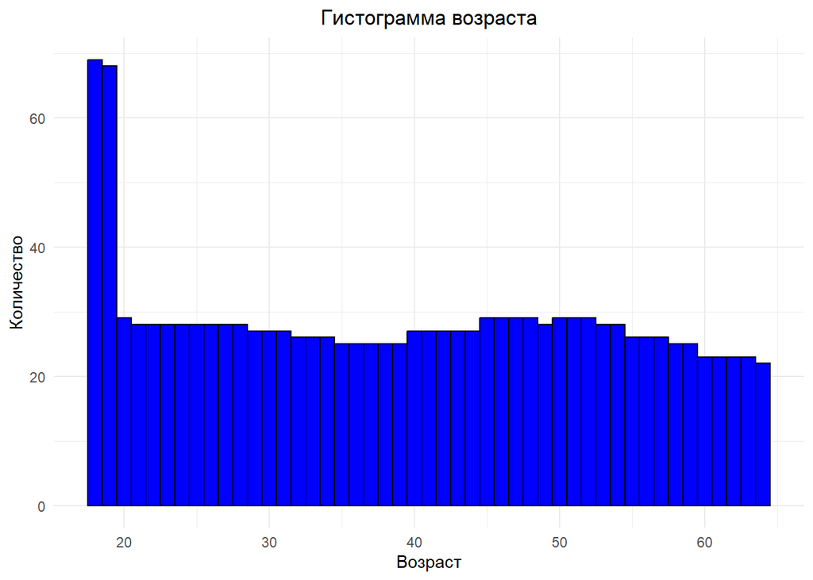

```r
# Гистограмма для переменной возраста (age)
ggplot(insurance_cost, aes(x = age)) +
  geom_histogram(binwidth = 1, fill = "blue", color = "black") +
  labs(title = "Гистограмма возраста", x = "Возраст", y = "Количество") +
  theme_minimal()+
  theme(plot.title = element_text(hjust = 0.5))
```

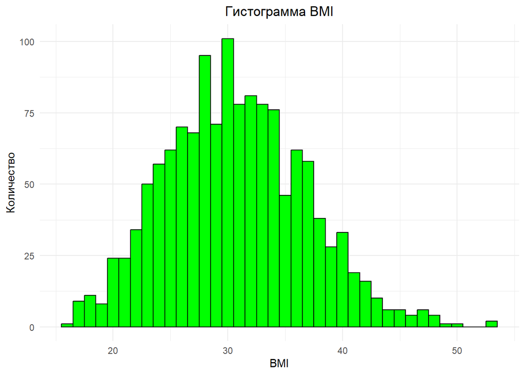

```r
# Гистограмма для переменной BMI (bmi)
ggplot(insurance_cost, aes(x = bmi)) +
  geom_histogram(binwidth = 1, fill = "green", color = "black") +
  labs(title = "Гистограмма BMI", x = "BMI", y = "Количество") +
  theme_minimal()+
  theme(plot.title = element_text(hjust = 0.5))
```

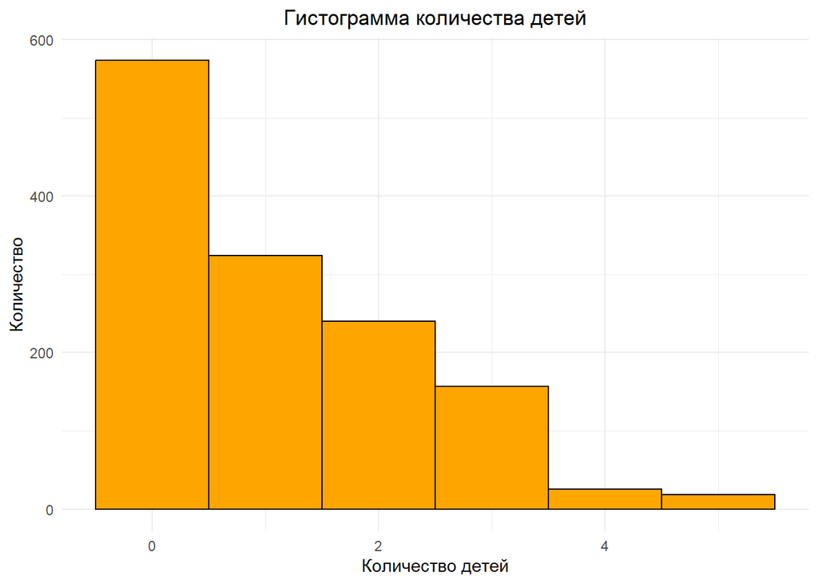

```r
# Гистограмма для переменной количества детей (children)
ggplot(insurance_cost, aes(x = children)) +
  geom_histogram(binwidth = 1, fill = "orange", color = "black") +
  labs(title = "Гистограмма количества детей", x = "Количество детей", y = "Количество") +
  theme_minimal()+
  theme(plot.title = element_text(hjust = 0.5))
```

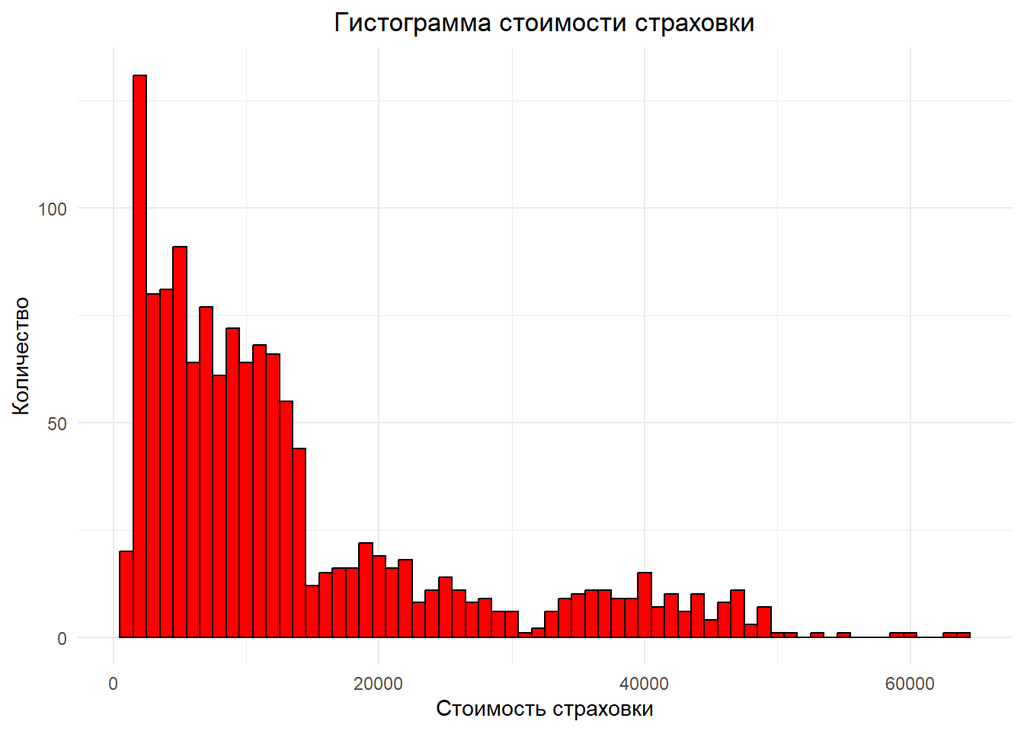

```r
# Гистограмма для переменной стоимости страховки (charges)
ggplot(insurance_cost, aes(x = charges)) +
  geom_histogram(binwidth = 1000, fill = "red", color = "black") +
  labs(title = "Гистограмма стоимости страховки", x = "Стоимость страховки", y = "Количество") +
  theme_minimal()+
  theme(plot.title = element_text(hjust = 0.5))
```

Задание №3. Нарисуйте график плотности по колонке charges. Отметьте вертикальные линии средней и медианы на графике. Раскрасьте текст и линии средней и медианы разными цветами. Добавьте текстовые пояснения значения средней и медианы. Подберите тему для графика. Назовите оси.

```r
# Вычислим среднее и медиану для переменной 'charges'
mean_charges <- mean(insurance_cost$charges)
median_charges <- median(insurance_cost$charges)

# График плотности для переменной 'charges'
charges_desity <- ggplot(insurance_cost, aes(x = charges)) +
  geom_density(fill = "lightblue", alpha = 0.5) +
  geom_vline(aes(xintercept = mean_charges), color = "red", linetype = "dashed", linewidth = 1) +
  geom_vline(aes(xintercept = median_charges), color = "blue", linetype = "dashed", linewidth = 1) +
  geom_text(aes(x = mean_charges, label = paste("Среднее:", round(mean_charges, 2)), y = 0.000002),
            color = "red", vjust = -20, hjust = -0.1) +
  geom_text(aes(x = median_charges, label = paste("Медиана:", round(median_charges, 2)), y = 0.000002),
            color = "blue", vjust = - 25, hjust = -0.1) +
  labs(title = "График плотности стоимости страховки", x = "Стоимость страховки", y = "Плотность") +
  theme_minimal()+
  theme(plot.title = element_text(hjust = 0.5))
```

Задание №4. Сделайте три box_plot по отношению переменных charges и (1) sex (2) smoker (3) region. Подберите тему для графика. Назовите оси.

```r
#install.packages("ggpubr")
library(ggpubr)
```

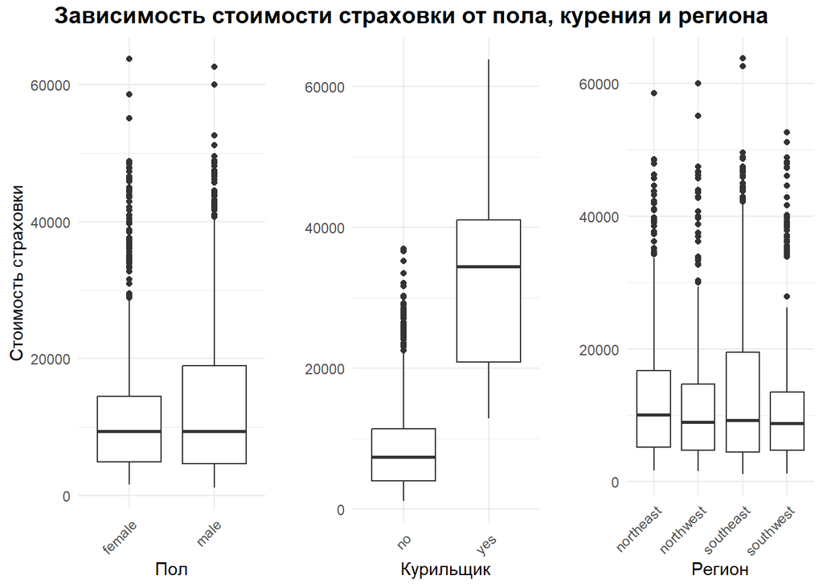

```r
# Создаем три отдельных графика
boxplot_sex <- ggplot(insurance_cost, aes(x = sex, y = charges)) +
  geom_boxplot() +
  labs(x = "Пол", y = "Стоимость страховки") +
  theme_minimal()+
  theme(axis.text.x = element_text(angle = 45, hjust = 1))# Поворот подписей на 45 градусов

boxplot_smoker <- ggplot(insurance_cost, aes(x = smoker, y = charges)) +
  geom_boxplot() +
  labs(x = "Курильщик", y = " ") +
  theme_minimal()+
  theme(axis.text.x = element_text(angle = 45, hjust = 1))# Поворот подписей на 45 градусов

boxplot_region <- ggplot(insurance_cost, aes(x = region, y = charges)) +
  geom_boxplot() +
  labs(x = "Регион", y = " ") +
  theme_minimal()+
  theme(axis.text.x = element_text(angle = 45, hjust = 1))# Поворот подписей на 45 градусов

# Используем ggarrange для объединения графиков
combined_boxplots <- ggarrange(boxplot_sex, boxplot_smoker, boxplot_region,
                               ncol = 3, nrow = 1,
                               common.legend = TRUE, legend = "bottom")

# Добавляем общий заголовок с помощью annotate_figure
combined_boxplots_with_title <- annotate_figure(combined_boxplots,
                                                top = text_grob("Зависимость стоимости страховки от пола, курения и региона",
                                                                size = 14, face = "bold"))

# Выводим график на экран
print(combined_boxplots_with_title)
```

Задание №5.Объедините графики из заданий 3 и 4 в один так, чтобы сверху шёл один график из задания 3, а под ним 3 графика из задания 4. Сделайте общее название для графика.

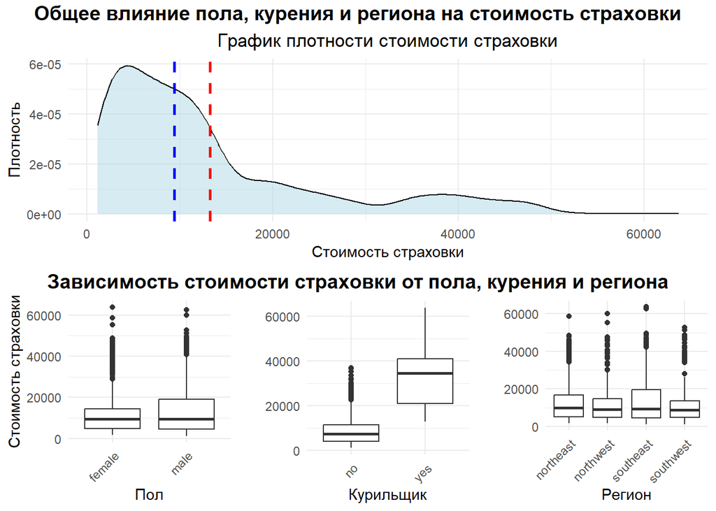

```r
# Используем ggarrange для объединения графиков
combined_plots <- ggarrange(charges_desity, # График из задания 3
                            combined_boxplots_with_title, # Графики из задания 4
                            ncol = 1, nrow = 2, # Один столбец, две строки
                            common.legend = TRUE, legend = "bottom") # Общая легенда

# Добавляем общий заголовок с помощью annotate_figure
combined_plots_with_title <- annotate_figure(combined_plots,
                                             top = text_grob("Общее влияние пола, курения и региона на стоимость страховки",
                                                             size = 14, face = "bold"))

# Выводим график на экран
print(combined_plots_with_title)
```

Задание №6. Сделайте фасет графика из задания 3 по колонке region.

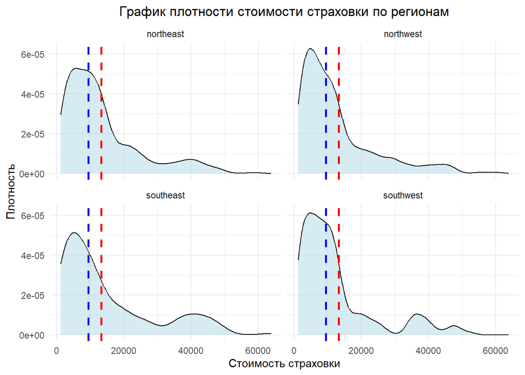

```r
# График плотности для переменной 'charges' по региону
charges_density_facet <- ggplot(insurance_cost, aes(x = charges)) +
  geom_density(fill = "lightblue", alpha = 0.5) +
  geom_vline(aes(xintercept = mean_charges), color = "red", linetype = "dashed", linewidth = 1) +
  geom_vline(aes(xintercept = median_charges), color = "blue", linetype = "dashed", linewidth = 1) +
  geom_text(aes(x = mean_charges, label = paste("Среднее:", round(mean_charges, 2)), y = 0.000002),
            color = "red", vjust = -20, hjust = -0.1) +
  geom_text(aes(x = median_charges, label = paste("Медиана:", round(median_charges, 2)), y = 0.000002),
            color = "blue", vjust = - 25, hjust = -0.1) +
  labs(title = "График плотности стоимости страховки по регионам",
       x = "Стоимость страховки", y = "Плотность") +
  facet_wrap(~ region) +
  theme_minimal() +
  theme(plot.title = element_text(hjust = 0.5))

# Выводим график на экран
print(charges_density_facet)
```

Задание №7. Постройте scatter plot отношения переменных age и charges. Добавьте названия осей, название графика и тему. Сделайте так, чтобы числа по оси Х отображались 14 шрифтом.

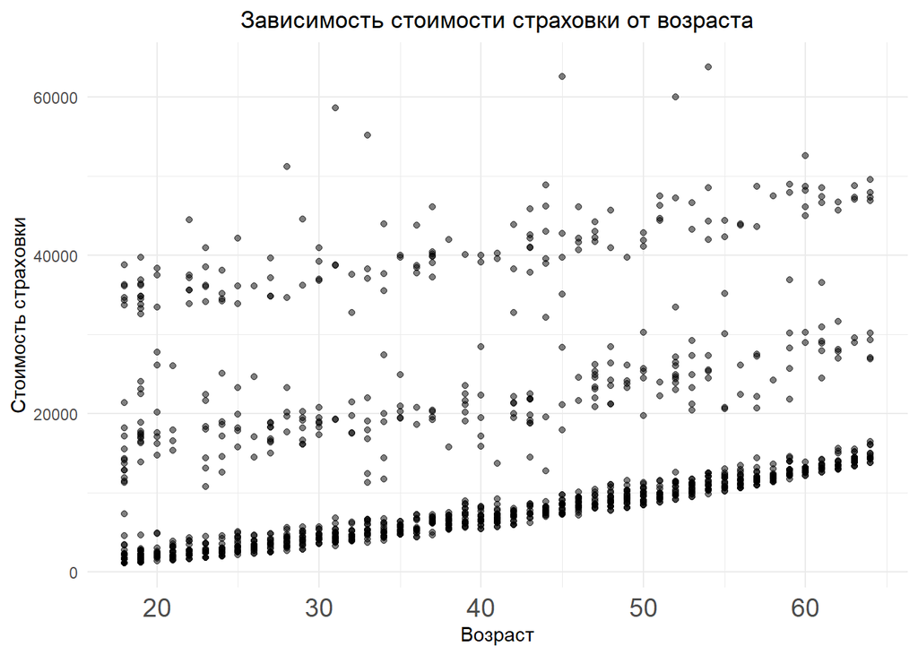

```r
# Scatter plot для отношения переменных 'age' и 'charges'
scatter_plot <- ggplot(insurance_cost, aes(x = age, y = charges)) +
  geom_point(alpha = 0.5) +  # Добавляем точки на график с небольшой прозрачностью
  labs(title = "Зависимость стоимости страховки от возраста",
       x = "Возраст",
       y = "Стоимость страховки") +
  theme_minimal() +
  theme(plot.title = element_text(hjust = 0.5),  # Центрируем заголовок
        axis.text.x = element_text(size = 14))  # Увеличиваем размер шрифта для оси X

# Выводим график на экран
print(scatter_plot)
```

Задание №8.Проведите линию тренда для предыдущего графика.

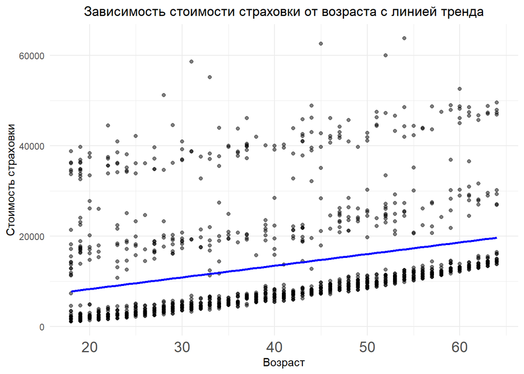

```r
# Scatter plot с линией тренда для отношения переменных 'age' и 'charges'
scatter_plot_with_trend <- ggplot(insurance_cost, aes(x = age, y = charges)) +
  geom_point(alpha = 0.5) +  # Добавляем точки на график с небольшой прозрачностью
  geom_smooth(method = "lm", se = FALSE, color = "blue") +  # Добавляем линию тренда
  labs(title = "Зависимость стоимости страховки от возраста с линией тренда",
       x = "Возраст",
       y = "Стоимость страховки") +
  theme_minimal() +
  theme(plot.title = element_text(hjust = 0.5),  # Центрируем заголовок
        axis.text.x = element_text(size = 14))  # Увеличиваем размер шрифта для оси X

# Выводим график на экран
print(scatter_plot_with_trend)
```

Задание №9. Сделайте разбивку предыдущего графика по колонке smokers (у вас должно получится две линии тренда для курящих и нет).

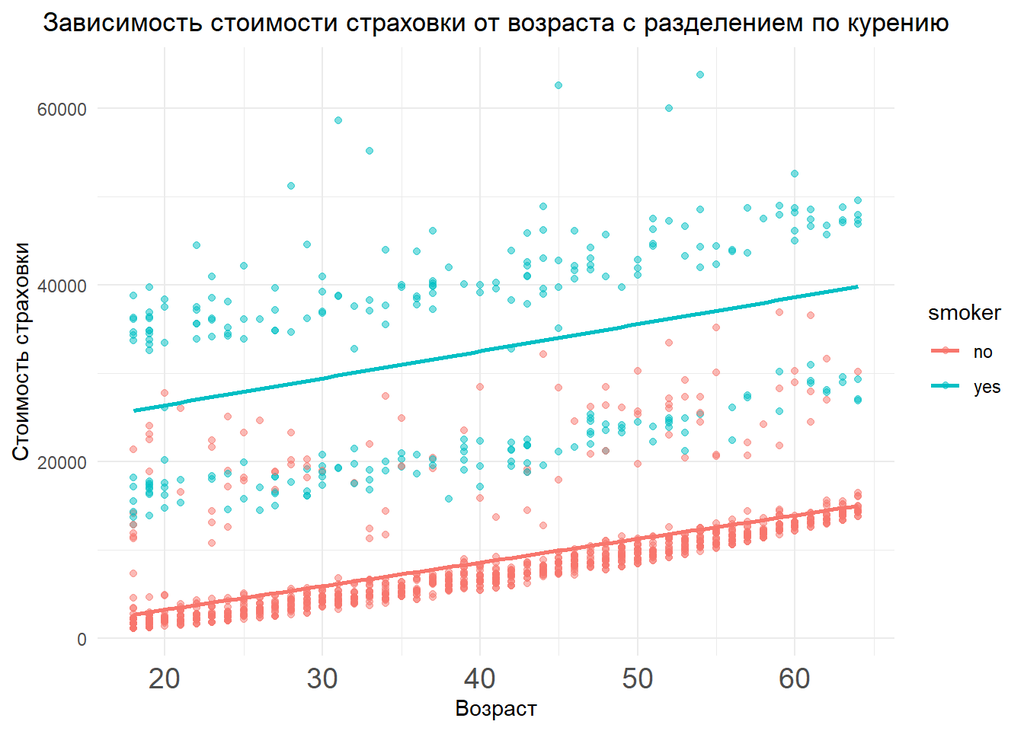

```r
# Scatter plot с двумя линиями тренда для отношения переменных 'age' и 'charges', разделенных по 'smoker'
scatter_plot_with_trend_smokers <- ggplot(insurance_cost, aes(x = age, y = charges, color = smoker)) +
  geom_point(alpha = 0.5) +  # Добавляем точки с прозрачностью
  geom_smooth(method = "lm", se = FALSE, aes(group = smoker)) +  # Добавляем линии тренда по группам
  labs(title = "Зависимость стоимости страховки от возраста с разделением по курению",
       x = "Возраст",
       y = "Стоимость страховки") +
  theme_minimal() +
  theme(plot.title = element_text(hjust = 0.5),  # Центрируем заголовок
        axis.text.x = element_text(size = 14))  # Увеличиваем размер шрифта для оси X

# Выводим график на экран
print(scatter_plot_with_trend_smokers)
```

Задание №10. Сделайте график из заданий 7-9, но вместо переменной age используйте переменную bmi.

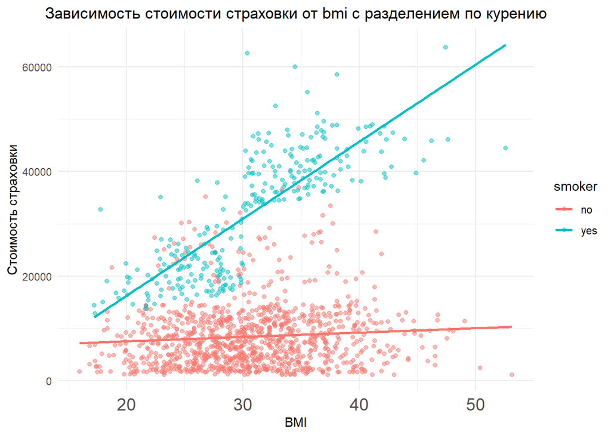

```r
# Scatter plot с двумя линиями тренда для отношения переменных 'bmi' и 'charges', разделенных по 'smoker'
scatter_plot_bmi__with_trend_smokers <- ggplot(insurance_cost, aes(x = bmi, y = charges, color = smoker)) +
  geom_point(alpha = 0.5) +  # Добавляем точки с прозрачностью
  geom_smooth(method = "lm", se = FALSE, aes(group = smoker)) +  # Добавляем линии тренда по группам
  labs(title = "Зависимость стоимости страховки от bmi с разделением по курению",
       x = "BMI",
       y = "Стоимость страховки") +
  theme_minimal() +
  theme(plot.title = element_text(hjust = 0.5),  # Центрируем заголовок
        axis.text.x = element_text(size = 14))  # Увеличиваем размер шрифта для оси X

# Выводим график на экран
print(scatter_plot_bmi__with_trend_smokers)
```

Задание №11.Самостоятельно задайте вопрос №1 к данным (вопрос должен быть про какую-то подвыборку данных). Ответьте на него построив график на подвыборке данных. График должен содержать все основные элементы оформления (название, подписи осей, тему и проч.). Аргументируйте выбор типа графика.

*Вопрос №1. Как распределяются медицинские расходы среди некурящих и курящих людей в разных возрастных группах?*

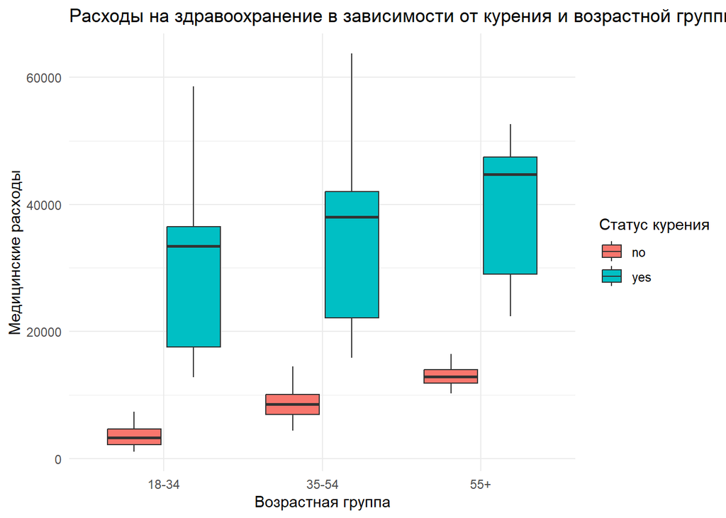

```r
# Подготовка данных для графика
insurance_cost$age_group <- cut(insurance_cost$age,
                                breaks = c(18, 35, 55, Inf),
                                labels = c("18-34", "35-54", "55+"),
                                include.lowest = TRUE,
                                right = FALSE)

# Фильтрация данных, чтобы исключить NA значения
insurance_cost <- insurance_cost[!is.na(insurance_cost$smoker),]

# Построение графика
p <- ggplot(insurance_cost, aes(x = age_group, y = charges, fill = smoker)) +
  geom_boxplot(outlier.shape = NA) + # Убираем выбросы для наглядности
  labs(title = "Расходы на здравоохранение в зависимости от курения и возрастной группы",
       x = "Возрастная группа",
       y = "Медицинские расходы",
       fill = "Статус курения") +
  theme_minimal() +
  theme(plot.title = element_text(hjust = 0))

# Печать графика
print(p)
```

Boxplot использовался для сравнения распределений медицинских расходов между курящими и некурящими людьми в разных возрастных группах.Обоснование типа графика:

1. *Сравнение групп*: Boxplot удобен для сравнения нескольких групп. В вашем случае он позволяет сравнить медицинские расходы между курящими и некурящими в каждой возрастной категории, делая сравнение наглядным.
2. *Сравнение медиан*: Boxplot показывает медианное значение расходов для каждой группы, что является надёжной мерой центральной тенденции.
3. *Межквартильный размах*: “Ящики” отображают межквартильный размах, что даёт представление о концентрации распределения данных и вариабельности расходов внутри групп.
4. *Выбросы*: “Усы” графика указывают на диапазон данных, исключая выбросы. Это даёт возможность увидеть, насколько расходы для некоторых отличаются от общей тенденции.

Задание №12.Самостоятельно задайте вопрос №2 к данным (вопрос должен быть про какую-то подвыборку данных). Ответьте на него построив график на подвыборке данных. График должен содержать все основные элементы оформления (название, подписи осей, тему и проч.). Аргументируйте выбор типа графика.

*Вопрос №2: Как индекс массы тела (BMI) влияет на средние годовые медицинские расходы в подвыборке курящих и некурящих людей в каждом возрасте?*

Обоснование типа графика: точечный график позволит нам увидеть распределение индивидуальных значений медицинских расходов в зависимости от BMI для каждой подгруппы (курящие/некурящие), а линейный график поможет визуализировать общую тенденцию среди этих значений.

```r
library(dplyr)
```

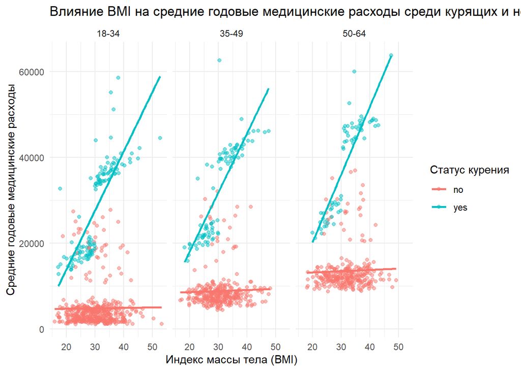

```r
insurance_cost <- insurance_cost %>%
  mutate(age_group = cut(age, breaks=c(18, 35, 50, 65, 100),
                         labels=c("18-34", "35-49", "50-64", "65+"),
                         include.lowest=TRUE))

# Теперь построим график
ggplot(insurance_cost, aes(x=bmi, y=charges, color=smoker)) +
  geom_point(alpha=0.5) +
  geom_smooth(aes(group=smoker), method="lm", se=FALSE) + # Линии тренда без доверительных интервалов
  facet_wrap(~age_group) + # Разделяем график по возрастным группам
  labs(title="Влияние BMI на средние годовые медицинские расходы среди курящих и некурящих",
       x="Индекс массы тела (BMI)",
       y="Средние годовые медицинские расходы",
       color="Статус курения") +
  theme_minimal()
```

Тип графика точечный с линиями тренда позволяет наглядно сравнить две группы по нескольким возрастным категориям, а также показать разницу в влиянии BMI на медицинские расходы между курящими и некурящими.

Задание №13.Самостоятельно задайте вопрос №3 к данным (вопрос должен быть про какую-то подвыборку данных). Ответьте на него построив график на подвыборке данных. График должен содержать все основные элементы оформления (название, подписи осей, тему и проч.). Аргументируйте выбор типа графика.

*Вопрос №3. Каково соотношение средних годовых медицинских расходов между мужчинами и женщинами в разных возрастных категориях?*

Обоснование типа графика: этот тип графика позволит наглядно сравнить расходы между двумя полами в разных возрастных группах.

```r
insurance_cost <- insurance_cost %>%
  mutate(age_group = cut(age, breaks=c(18, 35, 50, 65, 100),
                         labels=c("18-34", "35-49", "50-64", "65+"),
                         include.lowest=TRUE))

# Рассчитываем средние расходы для каждой возрастной категории и пола
average_costs_by_age <- insurance_cost %>%
  group_by(age_group, sex) %>%
  summarize(average_cost = mean(charges))
```

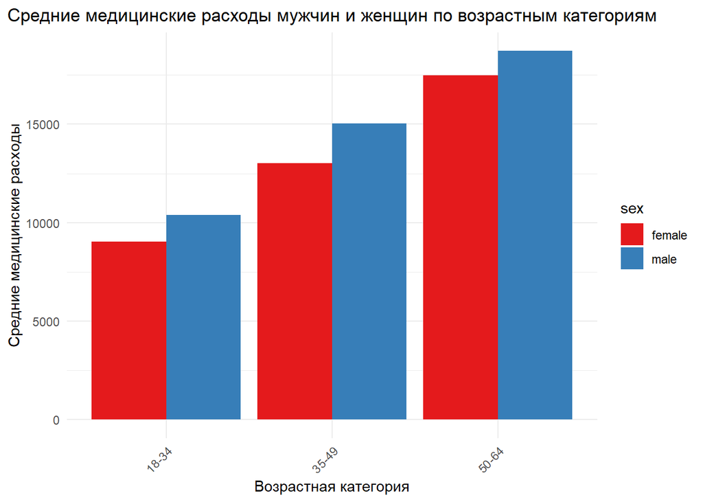

```r
# Строим график
ggplot(average_costs_by_age, aes(x = age_group, y = average_cost, fill = sex)) +
  geom_bar(stat = "identity", position = position_dodge()) +
  labs(title = "Cредние медицинские расходы мужчин и женщин по возрастным категориям",
       x = "Возрастная категория",
       y = "Средние медицинские расходы") +
  scale_fill_brewer(palette = "Set1") +
  theme_minimal() +
  theme(plot.title = element_text(hjust = 0.5),
        axis.text.x = element_text(angle = 45, hjust = 1))
```